# Estudi provisional STACOV - v2

Eudald Correig

26 juny, 2020

# Formateig

Traiem les resines i l’omacor perquè tenen massa poca variabilitat.

Nota: canvio el nom d’Antiagregants.Anticoagulants a A.A perquè si no ocupa massa i les coses es veuen malament.

Mirem quantes dates d’ingrés o alta ens falten:

Hi ha 2 pacients dels quals no tenim la data d’ingrés. Els traiem.

Fem una variable que controla quin esdeveniment de sortida (outcome) té cada pacient:

Hi ha encara algun pacient que té 0 dies d’estada:

```
##  [1] "3-093"  "3-099"  "09-101" "09-120" "10-107" "11-044" "13-129"
##  [8] "13-197" "19-022" "20-074"
```

Sumem un dia a tots

Traiem els pacients que tenen pes 0.

La distribució dels temps de seguiment és la següent:

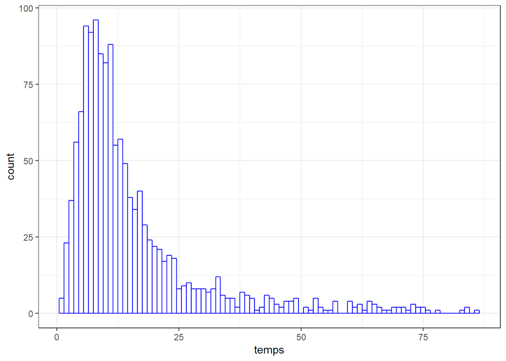

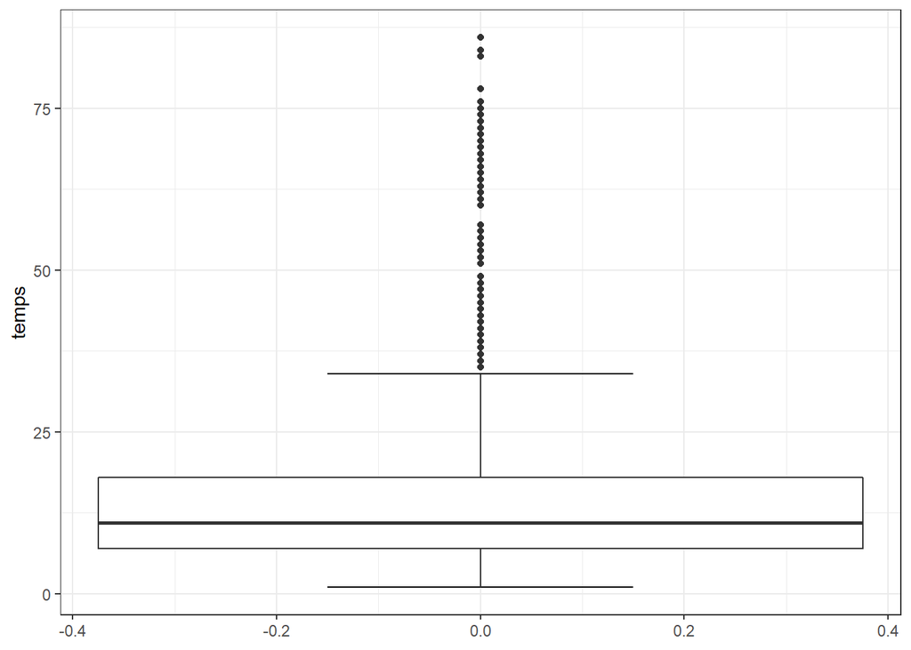

Els descriptius del temps de seguiment són:

```
## df$temps
##        n  missing distinct     Info     Mean      Gmd      .05      .10
##     1350        0       77    0.998    15.54    13.04        4        5
##      .25      .50      .75      .90      .95
##        7       11       18       33       47
##
## lowest :  1  2  3  4  5, highest: 76 78 83 84 86
```

# Descriptiu estatines

## No matxejat

| Variable | Levels | All | No estatins | Statins | p-value |
| --- | --- | --- | --- | --- | --- |
| Edat | – | 67 [54 78] | 62 [51 77] | 73 [65 80] | 0 |
| Sexe | Dona | 926 (42.81%) | 701 (44.4%) | 225 (38.53%) | 0.01641 |
| Sexe | Home | 1237 (57.19%) | 878 (55.6%) | 359 (61.47%) | 0.01641 |
| Tabac | No | 1562 (72.21%) | 1204 (76.25%) | 358 (61.3%) | 0 |
| Tabac | Exfumador | 493 (22.79%) | 299 (18.94%) | 194 (33.22%) | 0 |
| Tabac | Sí | 108 (4.99%) | 76 (4.81%) | 32 (5.48%) | 0 |
| HTA | No | 1079 (49.88%) | 941 (59.59%) | 138 (23.63%) | 0 |
| HTA | Sí | 1084 (50.12%) | 638 (40.41%) | 446 (76.37%) | 0 |
| Hiperlipemia | No | 1342 (62.04%) | 1295 (82.01%) | 47 (8.05%) | 0 |
| Hiperlipemia | Sí | 821 (37.96%) | 284 (17.99%) | 537 (91.95%) | 0 |
| Diabetes | No | 1660 (76.75%) | 1335 (84.55%) | 325 (55.65%) | 0 |
| Diabetes | Sí | 503 (23.25%) | 244 (15.45%) | 259 (44.35%) | 0 |
| Obesitat | No | 1582 (73.14%) | 1214 (76.88%) | 368 (63.01%) | 0 |
| Obesitat | Sí | 581 (26.86%) | 365 (23.12%) | 216 (36.99%) | 0 |
| Ant.CI | No | 1958 (90.52%) | 1524 (96.52%) | 434 (74.32%) | 0 |
| Ant.CI | Sí | 205 (9.48%) | 55 (3.48%) | 150 (25.68%) | 0 |
| Ant.Ictus | No | 2028 (93.76%) | 1518 (96.14%) | 510 (87.33%) | 0 |
| Ant.Ictus | Sí | 135 (6.24%) | 61 (3.86%) | 74 (12.67%) | 0 |
| Ant.MVP | No | 2062 (95.33%) | 1544 (97.78%) | 518 (88.7%) | 0 |
| Ant.MVP | Sí | 101 (4.67%) | 35 (2.22%) | 66 (11.3%) | 0 |
| Ant.Ins.Card | No | 1980 (91.54%) | 1481 (93.79%) | 499 (85.45%) | 0 |
| Ant.Ins.Card | Sí | 183 (8.46%) | 98 (6.21%) | 85 (14.55%) | 0 |
| Ant.MPOC.Asma | No | 1796 (83.03%) | 1350 (85.5%) | 446 (76.37%) | 0 |
| Ant.MPOC.Asma | Sí | 367 (16.97%) | 229 (14.5%) | 138 (23.63%) | 0 |
| Ant.MHepC | No | 2105 (97.32%) | 1535 (97.21%) | 570 (97.6%) | 0.72807 |
| Ant.MHepC | Sí | 58 (2.68%) | 44 (2.79%) | 14 (2.4%) | 0.72807 |
| Ant.MRC | No | 1945 (89.92%) | 1467 (92.91%) | 478 (81.85%) | 0 |
| Ant.MRC | Sí | 218 (10.08%) | 112 (7.09%) | 106 (18.15%) | 0 |
| Ant.MReu | No | 2058 (95.15%) | 1511 (95.69%) | 547 (93.66%) | 0.06624 |
| Ant.MReu | Sí | 105 (4.85%) | 68 (4.31%) | 37 (6.34%) | 0.06624 |

[output cut: 94 more lines]

## Matxejat

| Variable | Levels | All | No estatins | Statins | p-value |
| --- | --- | --- | --- | --- | --- |
| Edat | – | 74 [65 83] | 76 [65 84] | 73 [65 80] | 0.05805 |
| Sexe | Dona | 536.27 (39.72%) | 311.27 (40.58%) | 225 (38.59%) | 0.49427 |
| Sexe | Home | 813.73 (60.28%) | 455.73 (59.42%) | 358 (61.41%) | 0.49427 |
| Tabac | No | 839 (62.15%) | 482 (62.84%) | 357 (61.23%) | 0.42417 |
| Tabac | Exfumador | 427.78 (31.69%) | 233.78 (30.48%) | 194 (33.28%) | 0.42417 |
| Tabac | Sí | 83.22 (6.16%) | 51.22 (6.68%) | 32 (5.49%) | 0.42417 |
| HTA | No | 295.6 (21.9%) | 157.6 (20.55%) | 138 (23.67%) | 0.19092 |
| HTA | Sí | 1054.4 (78.1%) | 609.4 (79.45%) | 445 (76.33%) | 0.19092 |
| Hiperlipemia | No | 110.04 (8.15%) | 63.04 (8.22%) | 47 (8.06%) | 0.99656 |
| Hiperlipemia | Sí | 1239.96 (91.85%) | 703.96 (91.78%) | 536 (91.94%) | 0.99656 |
| Diabetes | No | 768.91 (56.96%) | 443.91 (57.88%) | 325 (55.75%) | 0.46683 |
| Diabetes | Sí | 581.09 (43.04%) | 323.09 (42.12%) | 258 (44.25%) | 0.46683 |
| Obesitat | No | 885.46 (65.59%) | 517.46 (67.47%) | 368 (63.12%) | 0.10821 |
| Obesitat | Sí | 464.54 (34.41%) | 249.54 (32.53%) | 215 (36.88%) | 0.10821 |
| Ant.CI | No | 1013.5 (75.07%) | 580.5 (75.68%) | 433 (74.27%) | 0.59517 |
| Ant.CI | Sí | 336.5 (24.93%) | 186.5 (24.32%) | 150 (25.73%) | 0.59517 |
| Ant.Ictus | No | 1189.32 (88.1%) | 680.32 (88.7%) | 509 (87.31%) | 0.48562 |
| Ant.Ictus | Sí | 160.68 (11.9%) | 86.68 (11.3%) | 74 (12.69%) | 0.48562 |
| Ant.MVP | No | 1206.51 (89.37%) | 689.51 (89.9%) | 517 (88.68%) | 0.52862 |
| Ant.MVP | Sí | 143.49 (10.63%) | 77.49 (10.1%) | 66 (11.32%) | 0.52862 |
| Ant.Ins.Card | No | 1169.11 (86.6%) | 671.11 (87.5%) | 498 (85.42%) | 0.30331 |
| Ant.Ins.Card | Sí | 180.89 (13.4%) | 95.89 (12.5%) | 85 (14.58%) | 0.30331 |
| Ant.MPOC | No | 1043.89 (77.33%) | 598.89 (78.08%) | 445 (76.33%) | 0.48627 |
| Ant.MPOC | Sí | 306.11 (22.67%) | 168.11 (21.92%) | 138 (23.67%) | 0.48627 |
| Ant.MHepC | No | 1320.24 (97.8%) | 751.24 (97.95%) | 569 (97.6%) | 0.80841 |
| Ant.MHepC | Sí | 29.76 (2.2%) | 15.76 (2.05%) | 14 (2.4%) | 0.80841 |
| Ant.MRC | No | 1118.92 (82.88%) | 640.92 (83.56%) | 478 (81.99%) | 0.49233 |
| Ant.MRC | Sí | 231.08 (17.12%) | 126.08 (16.44%) | 105 (18.01%) | 0.49233 |
| Ant.MReu | No | 1239.11 (91.79%) | 693.11 (90.37%) | 546 (93.65%) | 0.03762 |
| Ant.MReu | Sí | 110.89 (8.21%) | 73.89 (9.63%) | 37 (6.35%) | 0.03762 |

[output cut: 89 more lines]

Alerta perquè aquí hi ha valors no enters en alguns casos perquè estem tenin en compte els pesos (és a dir, podem tenir, per exemple, 100.4 persones que fumen i porten estatines)

# Anàlisi univariant

Fem un test de chi^2 per entre prendre estatines o no i morir de covid o no:

```
##
##
##    Cell Contents
## |-------------------------|
## |                       N |
## | Chi-square contribution |
## |           N / Row Total |
## |           N / Col Total |
## |         N / Table Total |
## |-------------------------|
##
##
## Total Observations in Table:  1350
##
##
##              |               No |               Sí |        Row Total |
## -------------|------------------|------------------|------------------|
##           No |              587 |              179 |              766 |
##              |            0.227 |            0.811 |                  |
##              |            0.766 |            0.234 |            0.568 |
##              |            0.557 |            0.608 |                  |
##              |            0.435 |            0.133 |                  |
## -------------|------------------|------------------|------------------|
##           Sí |              467 |              116 |              583 |
##              |            0.299 |            1.066 |                  |
##              |            0.801 |            0.199 |            0.432 |
##              |            0.443 |            0.392 |                  |
##              |            0.346 |            0.086 |                  |
## -------------|------------------|------------------|------------------|
## Column Total |             1054 |              295 |             1349 |
##              |            0.781 |            0.219 |                  |
## -------------|------------------|------------------|------------------|
##
##
## Statistics for All Table Factors
##
##
## Pearson's Chi-squared test
## ------------------------------------------------------------
## Chi^2 =  2.403131     d.f. =  1     p =  0.1210927
##
## Pearson's Chi-squared test with Yates' continuity correction
## ------------------------------------------------------------
## Chi^2 =  2.201582     d.f. =  1     p =  0.1378692
##
##
```

Fem un gràfic:

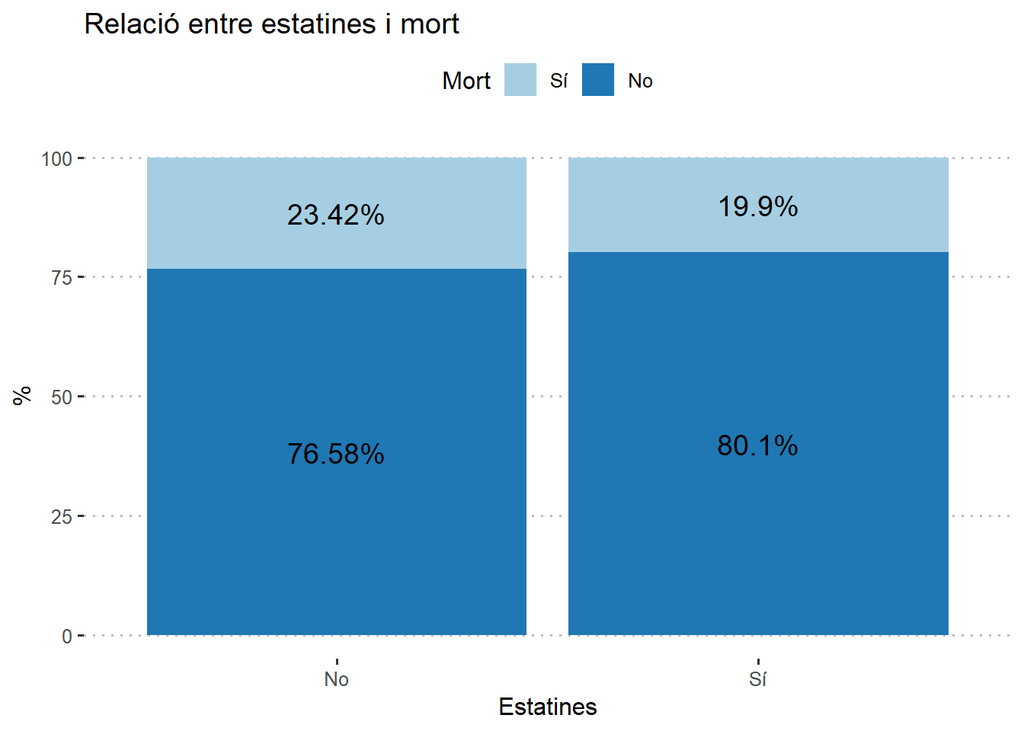

# Model de supervivència

Primer dibuixem una Kaplan Meier (per nosaltres, és per posar a l’article, però a mi m’agraden):

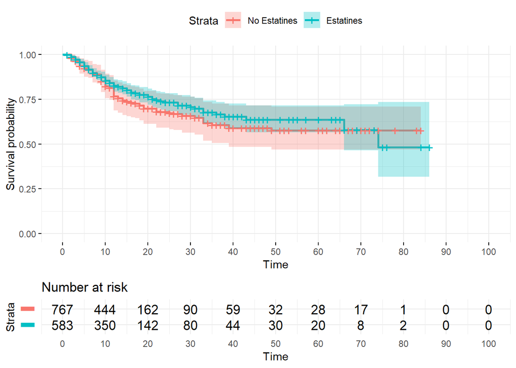

Ara fem un anàlisi de Cause Specific Hazard Ratio

## Cause specific hazard ratio

Tenim els següents esdeveniments:

```
##
## censura    alta    mort
##      89    1028     233
```

### Mort

```
## Call:
## coxph(formula = Surv(as.numeric(temps), esdeveniment == "mort") ~
##     . - Mort - weights, data = df, weights = df$weights, ties = "efron")
##
##   n= 1350, number of events= 233
##
##                     coef exp(coef)  se(coef) robust se      z Pr(>|z|)
## Edat            0.070366  1.072900  0.007854  0.010634  6.617 3.67e-11 ***
## SexeHome        0.468180  1.597085  0.161238  0.288682  1.622 0.104849
## TabacExfumador  0.096936  1.101790  0.163663  0.262497  0.369 0.711917
## TabacSí         0.304045  1.355330  0.303499  0.515187  0.590 0.555081
## HTASí          -0.103457  0.901715  0.193903  0.277824 -0.372 0.709608
## HiperlipemiaSí  0.355167  1.426418  0.232202  0.272302  1.304 0.192127
## DiabetesSí     -0.199199  0.819386  0.219867  0.386992 -0.515 0.606736
## ObesitatSí      0.055783  1.057368  0.148316  0.207965  0.268 0.788520
## Ant.CISí       -0.734501  0.479745  0.182788  0.257324 -2.854 0.004312 **
## Ant.IctusSí     0.214167  1.238830  0.171418  0.262159  0.817 0.413965
## Ant.MVPSí       0.468867  1.598183  0.185161  0.303586  1.544 0.122484
## Ant.Ins.CardSí  0.207465  1.230555  0.175972  0.285612  0.726 0.467601
## Ant.MPOCSí      0.009895  1.009944  0.147762  0.235299  0.042 0.966458
## Ant.MHepCSí     0.514067  1.672078  0.372668  0.652736  0.788 0.430956
## Ant.MRCSí       0.312960  1.367467  0.150504  0.246658  1.269 0.204512
## Ant.MReuSí     -0.789790  0.453940  0.334779  0.449338 -1.758 0.078803 .
## CàncerSí        0.864251  2.373227  0.154598  0.258442  3.344 0.000826 ***
## EstatinesSí    -0.320780  0.725583  0.140171  0.207035 -1.549 0.121286
## EzetimibaSí     0.583036  1.791468  0.317284  0.760357  0.767 0.443205
## FibratSí        0.746517  2.109639  0.259252  0.404177  1.847 0.064747 .
## IECASí         -0.210763  0.809966  0.154845  0.240597 -0.876 0.381030
## ARA2Sí         -0.384813  0.680578  0.192476  0.288184 -1.335 0.181777
## InsulinaSí      0.237829  1.268492  0.208261  0.419420  0.567 0.570685
## ISGLT2Sí       -0.735717  0.479162  0.492834  0.825273 -0.891 0.372670
## GLP1Sí          0.477909  1.612699  0.312122  0.577183  0.828 0.407669
## Trac.DMSí       0.512194  1.668949  0.214991  0.393415  1.302 0.192944
## A.A.NACOs      -0.378999  0.684546  0.250489  0.399982 -0.948 0.343364
## A.A.No         -0.591847  0.553305  0.159493  0.261221 -2.266 0.023470 *
## A.A.Sintrom    -0.331964  0.717513  0.210690  0.367752 -0.903 0.366694
## CT              0.122515  1.130336  0.078819  0.130272  0.940 0.346985
## HDL             0.338930  1.403444  0.263639  0.357545  0.948 0.343163
## LDL            -0.225144  0.798401  0.121594  0.204022 -1.104 0.269799
## TG              0.046960  1.048080  0.042217  0.060740  0.773 0.439445
```

[output cut: 30 more lines]

```
## A.A.NACOs         0.6845     1.4608   0.31256    1.4992
## A.A.No            0.5533     1.8073   0.33160    0.9232
## A.A.Sintrom       0.7175     1.3937   0.34898    1.4752
## CT                1.1303     0.8847   0.87563    1.4591
## HDL               1.4034     0.7125   0.69639    2.8284
## LDL               0.7984     1.2525   0.53525    1.1909
## TG                1.0481     0.9541   0.93045    1.1806
##
## Concordance= 0.785  (se = 0.023 )
## Likelihood ratio test= 301.6  on 33 df,   p=<2e-16
## Wald test            = 128.9  on 33 df,   p=3e-13
## Score (logrank) test = 308.8  on 33 df,   p=<2e-16,   Robust = 68.46  p=3e-04
##
##   (Note: the likelihood ratio and score tests assume independence of
##      observations within a cluster, the Wald and robust score tests do not).
```

Forest plot:

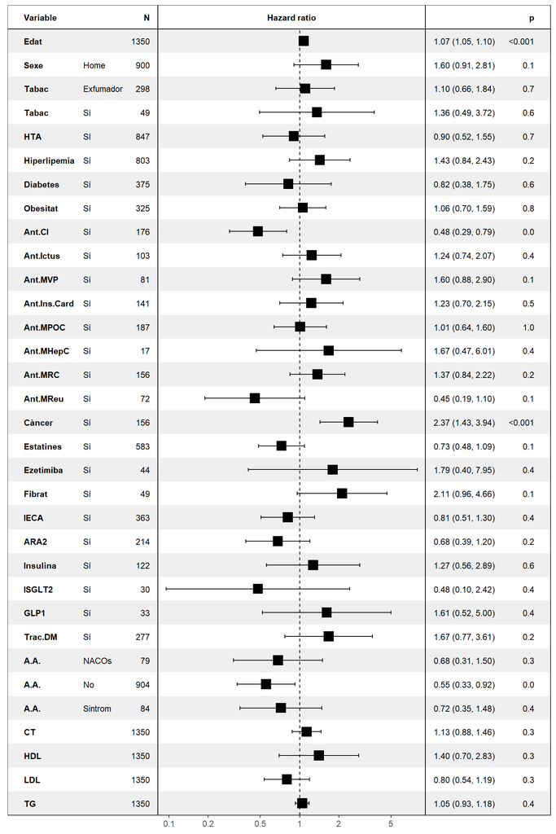

### Alta

```
## Call:
## coxph(formula = Surv(as.numeric(temps), df$esdeveniment == "alta") ~
##     . - weights - Mort, data = df, weights = df$weights, ties = "efron")
##
##   n= 1350, number of events= 1028
##
##                     coef exp(coef)  se(coef) robust se      z Pr(>|z|)
## Edat           -0.004109  0.995900  0.003330  0.004841 -0.849  0.39604
## SexeHome       -0.035007  0.965599  0.082048  0.117533 -0.298  0.76582
## TabacExfumador -0.012223  0.987851  0.086261  0.157547 -0.078  0.93816
## TabacSí        -0.437166  0.645864  0.184046  0.336000 -1.301  0.19323
## HTASí          -0.147095  0.863212  0.095708  0.126428 -1.163  0.24464
## HiperlipemiaSí  0.110591  1.116937  0.124092  0.169031  0.654  0.51294
## DiabetesSí      0.049159  1.050388  0.115276  0.159357  0.308  0.75771
## ObesitatSí      0.010239  1.010291  0.075894  0.122976  0.083  0.93365
## Ant.CISí        0.453359  1.573589  0.088875  0.164671  2.753  0.00590 **
## Ant.IctusSí     0.299653  1.349390  0.113617  0.184610  1.623  0.10455
## Ant.MVPSí      -0.570257  0.565380  0.140839  0.212884 -2.679  0.00739 **
## Ant.Ins.CardSí -0.055052  0.946436  0.120122  0.185573 -0.297  0.76673
## Ant.MPOCSí      0.132939  1.142180  0.084272  0.148093  0.898  0.36936
## Ant.MHepCSí    -0.237658  0.788472  0.291810  0.442561 -0.537  0.59126
## Ant.MRCSí       0.164915  1.179293  0.104650  0.204491  0.806  0.41998
## Ant.MReuSí     -0.500751  0.606075  0.131451  0.264657 -1.892  0.05848 .
## CàncerSí        0.170398  1.185777  0.104129  0.202248  0.843  0.39950
## EstatinesSí    -0.106647  0.898843  0.072881  0.144521 -0.738  0.46055
## EzetimibaSí     0.156277  1.169150  0.175517  0.206709  0.756  0.44963
## FibratSí       -0.161125  0.851185  0.147736  0.214092 -0.753  0.45169
## IECASí          0.067578  1.069913  0.087981  0.141777  0.477  0.63361
## ARA2Sí          0.158780  1.172080  0.099112  0.166708  0.952  0.34087
## InsulinaSí     -0.113727  0.892502  0.126781  0.160487 -0.709  0.47855
## ISGLT2Sí        0.334440  1.397158  0.193949  0.286403  1.168  0.24292
## GLP1Sí          0.268102  1.307481  0.200467  0.190625  1.406  0.15959
## Trac.DMSí      -0.274531  0.759929  0.116467  0.156996 -1.749  0.08035 .
## A.A.NACOs      -0.058810  0.942886  0.142787  0.175058 -0.336  0.73691
## A.A.No         -0.119244  0.887591  0.091443  0.161133 -0.740  0.45928
## A.A.Sintrom    -0.041738  0.959121  0.131508  0.237586 -0.176  0.86055
## CT             -0.177296  0.837532  0.079623  0.110428 -1.606  0.10838
## HDL             0.268988  1.308639  0.144615  0.221171  1.216  0.22391
## LDL             0.265835  1.304520  0.090291  0.131920  2.015  0.04389 *
## TG             -0.012186  0.987888  0.025628  0.042361 -0.288  0.77360
```

[output cut: 30 more lines]

```
## A.A.NACOs         0.9429     1.0606    0.6690    1.3288
## A.A.No            0.8876     1.1266    0.6472    1.2172
## A.A.Sintrom       0.9591     1.0426    0.6021    1.5279
## CT                0.8375     1.1940    0.6745    1.0399
## HDL               1.3086     0.7642    0.8483    2.0187
## LDL               1.3045     0.7666    1.0073    1.6894
## TG                0.9879     1.0123    0.9092    1.0734
##
## Concordance= 0.623  (se = 0.023 )
## Likelihood ratio test= 124.6  on 33 df,   p=1e-12
## Wald test            = 52.63  on 33 df,   p=0.02
## Score (logrank) test = 119.8  on 33 df,   p=9e-12,   Robust = 39.43  p=0.2
##
##   (Note: the likelihood ratio and score tests assume independence of
##      observations within a cluster, the Wald and robust score tests do not).
```

Forest plot:

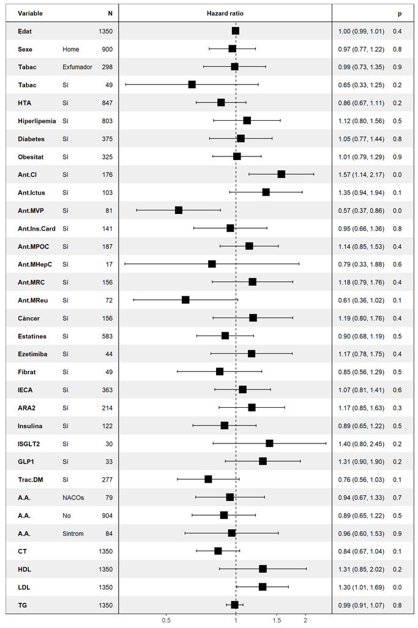

I acabem per un competing risk

## Competing risk

### Mort

```
## Call:
## coxph(formula = Surv(fgstart, fgstop, fgstatus) ~ . - Mort -
##     fgwt - weights, data = fg, weights = fgwt)
##
##   n= 2369, number of events= 233
##
##                     coef exp(coef)  se(coef) robust se      z Pr(>|z|)
## Edat            0.067006  1.069302  0.007778  0.010364  6.465 1.01e-10 ***
## SexeHome        0.311526  1.365508  0.160658  0.317145  0.982 0.325959
## TabacExfumador  0.067879  1.070235  0.165291  0.306053  0.222 0.824480
## TabacSí         0.560792  1.752060  0.288464  0.445244  1.260 0.207843
## HTASí          -0.108115  0.897525  0.199454  0.297551 -0.363 0.716345
## HiperlipemiaSí  0.220821  1.247100  0.233185  0.285927  0.772 0.439937
## DiabetesSí     -0.109016  0.896716  0.224983  0.410757 -0.265 0.790699
## ObesitatSí      0.018327  1.018496  0.147674  0.217901  0.084 0.932972
## Ant.CISí       -0.994328  0.369972  0.184872  0.294973 -3.371 0.000749 ***
## Ant.IctusSí     0.029511  1.029951  0.170988  0.304869  0.097 0.922886
## Ant.MVPSí       0.574245  1.775790  0.180010  0.302751  1.897 0.057859 .
## Ant.Ins.CardSí  0.232255  1.261442  0.175513  0.293265  0.792 0.428381
## Ant.MPOCSí      0.065930  1.068152  0.145123  0.250602  0.263 0.792485
## Ant.MHepCSí     0.425768  1.530765  0.363015  0.671657  0.634 0.526142
## Ant.MRCSí       0.265994  1.304727  0.151252  0.261303  1.018 0.308701
## Ant.MReuSí     -0.602674  0.547346  0.333432  0.427235 -1.411 0.158351
## CàncerSí        0.591452  1.806610  0.155050  0.308191  1.919 0.054971 .
## EstatinesSí    -0.242529  0.784641  0.136129  0.219587 -1.104 0.269387
## EzetimibaSí     0.491114  1.634136  0.307404  0.748134  0.656 0.511533
## FibratSí        0.776947  2.174822  0.256302  0.397322  1.955 0.050529 .
## IECASí         -0.199625  0.819038  0.155457  0.256058 -0.780 0.435621
## ARA2Sí         -0.407854  0.665076  0.192519  0.304748 -1.338 0.180788
## InsulinaSí      0.238271  1.269053  0.207226  0.418781  0.569 0.569381
## ISGLT2Sí       -0.705766  0.493730  0.502707  0.902358 -0.782 0.434135
## GLP1Sí          0.310068  1.363519  0.319739  0.622344  0.498 0.618324
## Trac.DMSí       0.543855  1.722634  0.216916  0.418674  1.299 0.193946
## A.A.NACOs      -0.305901  0.736460  0.243702  0.368798 -0.829 0.406847
## A.A.No         -0.549695  0.577126  0.159915  0.277760 -1.979 0.047813 *
## A.A.Sintrom    -0.365895  0.693576  0.216418  0.426461 -0.858 0.390904
## CT              0.155806  1.168600  0.080795  0.117391  1.327 0.184428
## HDL             0.146590  1.157879  0.264165  0.346699  0.423 0.672429
## LDL            -0.200563  0.818270  0.122697  0.204710 -0.980 0.327214
## TG              0.028441  1.028850  0.042232  0.065184  0.436 0.662601
```

[output cut: 30 more lines]

```
## A.A.NACOs         0.7365     1.3578   0.35746    1.5173
## A.A.No            0.5771     1.7327   0.33484    0.9947
## A.A.Sintrom       0.6936     1.4418   0.30067    1.5999
## CT                1.1686     0.8557   0.92842    1.4709
## HDL               1.1579     0.8636   0.58688    2.2844
## LDL               0.8183     1.2221   0.54783    1.2222
## TG                1.0288     0.9720   0.90546    1.1691
##
## Concordance= 0.767  (se = 0.023 )
## Likelihood ratio test= 281.1  on 33 df,   p=<2e-16
## Wald test            = 115.8  on 33 df,   p=4e-11
## Score (logrank) test = 287.5  on 33 df,   p=<2e-16,   Robust = 65.74  p=6e-04
##
##   (Note: the likelihood ratio and score tests assume independence of
##      observations within a cluster, the Wald and robust score tests do not).
```

### Alta

```
## Call:
## coxph(formula = Surv(fgstart, fgstop, fgstatus) ~ . - Mort -
##     fgwt - weights, data = fg, weights = fgwt)
##
##   n= 1580, number of events= 1028
##
##                     coef exp(coef)  se(coef) robust se      z Pr(>|z|)
## Edat           -0.018295  0.981872  0.003232  0.004846 -3.775 0.000160 ***
## SexeHome       -0.079784  0.923316  0.080491  0.126141 -0.632 0.527063
## TabacExfumador -0.039041  0.961711  0.086251  0.166246 -0.235 0.814332
## TabacSí        -0.432500  0.648885  0.182509  0.303409 -1.425 0.154022
## HTASí          -0.148018  0.862415  0.095597  0.137716 -1.075 0.282459
## HiperlipemiaSí -0.114600  0.891723  0.122266  0.157068 -0.730 0.465623
## DiabetesSí     -0.017706  0.982450  0.113926  0.181326 -0.098 0.922212
## ObesitatSí      0.054152  1.055646  0.074401  0.123253  0.439 0.660400
## Ant.CISí        0.627091  1.872157  0.089207  0.175579  3.572 0.000355 ***
## Ant.IctusSí     0.146959  1.158307  0.112649  0.214477  0.685 0.493218
## Ant.MVPSí      -0.685957  0.503608  0.140511  0.242107 -2.833 0.004607 **
## Ant.Ins.CardSí -0.163293  0.849342  0.116847  0.196880 -0.829 0.406877
## Ant.MPOCSí      0.121017  1.128644  0.084266  0.157634  0.768 0.442662
## Ant.MHepCSí    -0.471884  0.623826  0.293971  0.496449 -0.951 0.341849
## Ant.MRCSí      -0.031191  0.969290  0.104679  0.226321 -0.138 0.890384
## Ant.MReuSí     -0.334725  0.715535  0.131041  0.255586 -1.310 0.190319
## CàncerSí       -0.101233  0.903723  0.104539  0.225368 -0.449 0.653296
## EstatinesSí    -0.030286  0.970168  0.072666  0.148179 -0.204 0.838052
## EzetimibaSí     0.033302  1.033863  0.171868  0.238832  0.139 0.889105
## FibratSí       -0.312113  0.731899  0.147779  0.219932 -1.419 0.155860
## IECASí          0.132945  1.142187  0.087018  0.147097  0.904 0.366106
## ARA2Sí          0.282085  1.325891  0.098207  0.175886  1.604 0.108760
## InsulinaSí     -0.165872  0.847155  0.124972  0.189602 -0.875 0.381661
## ISGLT2Sí        0.423011  1.526551  0.188038  0.307398  1.376 0.168790
## GLP1Sí          0.098688  1.103722  0.197543  0.225106  0.438 0.661091
## Trac.DMSí      -0.212041  0.808931  0.114176  0.170030 -1.247 0.212368
## A.A.NACOs       0.084061  1.087696  0.139898  0.194866  0.431 0.666191
## A.A.No          0.077336  1.080405  0.090778  0.176627  0.438 0.661495
## A.A.Sintrom     0.219329  1.245241  0.133533  0.269071  0.815 0.414995
## CT             -0.206641  0.813311  0.080265  0.121613 -1.699 0.089287 .
## HDL             0.191674  1.211276  0.146959  0.233677  0.820 0.412072
## LDL             0.332216  1.394054  0.089515  0.134937  2.462 0.013816 *
## TG             -0.024140  0.976149  0.023888  0.042429 -0.569 0.569393
```

[output cut: 30 more lines]

```
## A.A.NACOs         1.0877     0.9194    0.7424    1.5936
## A.A.No            1.0804     0.9256    0.7643    1.5273
## A.A.Sintrom       1.2452     0.8031    0.7349    2.1100
## CT                0.8133     1.2295    0.6408    1.0322
## HDL               1.2113     0.8256    0.7662    1.9149
## LDL               1.3941     0.7173    1.0701    1.8161
## TG                0.9761     1.0244    0.8983    1.0608
##
## Concordance= 0.633  (se = 0.019 )
## Likelihood ratio test= 199.7  on 33 df,   p=<2e-16
## Wald test            = 90.84  on 33 df,   p=3e-07
## Score (logrank) test = 191  on 33 df,   p=<2e-16,   Robust = 65.67  p=6e-04
##
##   (Note: the likelihood ratio and score tests assume independence of
##      observations within a cluster, the Wald and robust score tests do not).
```